# 🐍 Sesión 02 — Manipulación, visualización y pipeline integrador (Python)

**Curso:** Fundamentos de programación en Python y R · **PEBIBA XVIII** · 2026 **Docente:** Cand. Dr. Jordan King Rodríguez Mallqui · UNI

## 📑 Índice

1. Recapitulación día 1 (Retrieval Practice) 🔁
2. Manipulación I: filtrar y seleccionar 🔍
3. Manipulación II: agrupar y agregar 📊
4. Method chaining: encadenar operaciones 🔗
5. ⚠️ Trampa #4: vectorización ⚡
6. Visualización con matplotlib y seaborn 📈
7. Heurística: ¿Python o R? 🤔
8. 🎯 Mini-pipeline integrador 🚀
9. 🏆 Resumen y siguiente paso

## 💼 Caso de Negocio (continuación)

**Recordemos:** la semana pasada cargaste el CSV de Acme Corp. Tu jefe sigue esperando la respuesta:

> *"Top 5 productos por ingresos Q4 por región — antes de la reunión del lunes."*

**Hoy la respondes** — y construyes el pipeline reproducible para que la próxima vez sea un clic.

## 🎯 Objetivos de Aprendizaje

Al final de este notebook podrás:

1. **Filtrar y seleccionar** datos con `.query()`, `.loc[]` y selección de columnas (CT-05).
2. **Agrupar y agregar** con `.groupby()` + `.agg()` para responder preguntas de negocio (CT-05).
3. **Encadenar operaciones** con method chaining para legibilidad (CT-05).
4. **Visualizar** datos con matplotlib y seaborn — gráficos correctos según el tipo de dato (CT-05 + CT-04 refuerzo).
5. **Decidir** Python vs R según el problema con criterios técnicos (CT-06).
6. **Construir** un mini-pipeline end-to-end reproducible (CT-07 — resultado terminal).

## 📂 Diccionario de Datos

Mismo dataset de S01: `acme_ventas.csv` (5,000 filas × 12 columnas). Ver diccionario completo en S01.

**Nueva columna calculada hoy:** `ingresos = cantidad × precio_unit × (1 - descuento_pct)`.

## 📦 Imports y Configuración

```python
from pathlib import Path

import pandas as pd
import numpy as np
import matplotlib.pyplot as plt
import seaborn as sns

# Configuración de pandas
pd.set_option('display.max_columns', 30)
pd.set_option('display.float_format', '{:.2f}'.format)

# Configuración de visualización (paleta UNI)
sns.set_theme(style='whitegrid', palette='deep')
plt.rcParams['figure.figsize'] = (10, 6)
plt.rcParams['axes.titlesize'] = 14
plt.rcParams['axes.titleweight'] = 'bold'

# Constantes
DATA_DIR = Path('../../01_Sesion_Sintaxis_Carga/data')
DATASET_FILENAME = 'acme_ventas.csv'

# Carga (de S01) + cálculo de columna ingresos
df = pd.read_csv(DATA_DIR / DATASET_FILENAME, parse_dates=['fecha'])
df['ingresos'] = df['cantidad'] * df['precio_unit'] * (1 - df['descuento_pct'])

print(f'Dataset cargado: {df.shape[0]:,} filas × {df.shape[1]} columnas')
print(f'Columna ingresos creada (rango: {df["ingresos"].min():.0f} a {df["ingresos"].max():.0f})')
```

```
Dataset cargado: 5,000 filas × 13 columnas
Columna ingresos creada (rango: 22 a 31046885)
```

## 1. Recapitulación día 1 🔁

Antes de avanzar, **verifica** que conservas los conceptos del día 1:

```python
# 5 mini-recall (escribe la respuesta como comentario y luego ejecuta para verificar)

# Q1: ¿Cuál es el primer elemento de [10, 20, 30] en Python?
# Respuesta: ___
lista = [10, 20, 30]
print(f'Q1: lista[0] = {lista[0]}')

# Q2: ¿Qué imprime?
x = [1, 2, 3]
y = x
y.append(4)
print(f'Q2: x = {x}')   # ← Trampa #1

# Q3: ¿Cómo cargo un CSV con encoding latin1 y separador ;?
# Respuesta: pd.read_csv(path, encoding='latin1', sep=';')

# Q4: ¿Qué método pandas muestra tipos y nulos?
# Respuesta: df.info()

# Q5: ¿Cuántas filas tiene df?
print(f'Q5: df tiene {len(df):,} filas')
```

```
Q1: lista[0] = 10
Q2: x = [1, 2, 3, 4]
Q5: df tiene 5,000 filas
```

## 2. Manipulación I: filtrar y seleccionar 🔍

**Idea clave:** filtrar = quedarse con FILAS que cumplan condición. Seleccionar = quedarse con COLUMNAS específicas.

```python
# Filtrar filas con .query()  — LEGIBLE
ventas_q4 = df.query("quarter == 'Q4'")
print(f'Filas en Q4: {len(ventas_q4):,}')

# Filtrar filas con .loc[] — más flexible
ventas_lima = df.loc[df['region'] == 'Lima']
print(f'Filas en Lima: {len(ventas_lima):,}')

# Combinar condiciones — usar paréntesis y operadores & | (no and/or)
ventas_q4_lima = df.loc[(df['region'] == 'Lima') & (df['quarter'] == 'Q4')]
print(f'Filas en Lima Q4: {len(ventas_q4_lima):,}')
```

```
Filas en Q4: 1,277
Filas en Lima: 860
Filas en Lima Q4: 229
```

### ⚠️ Real-World Warning: `&`/`|` no `and`/`or`

Cuando combinas condiciones en pandas, **usa `&` (and) y `|` (or)** — no `and`/`or` que dan error.

Y SIEMPRE pon paréntesis alrededor de cada condición:

```
# ✅ Correcto
df.loc[(df['x'] > 5) & (df['y'] < 10)]

# ❌ Error
df.loc[df['x'] > 5 and df['y'] < 10]
```

```python
# Seleccionar columnas (varias formas)
cols_clave = df[['region', 'producto', 'ingresos']]
cols_clave.head()
```

|  | region | producto | ingresos |
| --- | --- | --- | --- |
| 0 | Cusco | Monitor 27 4K | 6990.97 |
| 1 | Arequipa | Laptop Pro 15 | 109132.68 |
| 2 | Trujillo | Lámpara LED | 2064.83 |
| 3 | Trujillo | Resma Papel A4 | 961.20 |
| 4 | Arequipa | Cartucho Tinta Negra | 2132.37 |

### 🧠 Micro-Desafío 2.1

Usando `.query()` o `.loc[]`, **filtra** las ventas de la región Cusco con descuento ≥ 0.10. Cuenta cuántas son.

```python
# Solución
ventas_cusco_descuento = df.query("region == 'Cusco' and descuento_pct >= 0.10")
print(f'Ventas en Cusco con descuento ≥ 10%: {len(ventas_cusco_descuento):,}')
```

```
Ventas en Cusco con descuento ≥ 10%: 510
```

## 3. Manipulación II: agrupar y agregar 📊

**El "GROUP BY" de SQL** — pero más expresivo. Es el patrón más útil para responder preguntas de negocio.

```python
# Pregunta de negocio 1: total de ingresos por región
ingresos_por_region = df.groupby('region')['ingresos'].sum().sort_values(ascending=False)
ingresos_por_region
```

```
region
Trujillo   49430660.51
Lima       32701806.61
Cusco      24760279.89
Chiclayo   21990719.52
Piura      19512610.63
Arequipa   17503627.29
Name: ingresos, dtype: float64
```

```python
# Pregunta 2: agregaciones múltiples por región
resumen_region = df.groupby('region').agg(
    n_transacciones=('id_transaccion', 'count'),
    ingresos_totales=('ingresos', 'sum'),
    ingreso_promedio=('ingresos', 'mean'),
    cantidad_total=('cantidad', 'sum')
).round(2).sort_values('ingresos_totales', ascending=False)

resumen_region
```

| region | n_transacciones | ingresos_totales | ingreso_promedio | cantidad_total |
| --- | --- | --- | --- | --- |
| Trujillo | 882 | 49430660.51 | 56043.83 | 32296 |
| Lima | 860 | 32701806.61 | 38025.36 | 31664 |
| Cusco | 834 | 24760279.89 | 29688.58 | 40418 |
| Chiclayo | 817 | 21990719.52 | 26916.43 | 29986 |
| Piura | 796 | 19512610.63 | 24513.33 | 19795 |
| Arequipa | 811 | 17503627.29 | 21582.77 | 19780 |

### 💡 Pro-Tip: `.agg()` con sintaxis named-tuples

La sintaxis `nombre=('columna', 'operación')` es la moderna (pandas ≥ 0.25). Es legible, permite múltiples agregaciones de la misma columna, y nombra las salidas.

Operaciones comunes: `'sum'`, `'mean'`, `'median'`, `'count'`, `'nunique'`, `'std'`, `'min'`, `'max'`, `'first'`, `'last'`.

```python
# Pregunta 3: agrupar por DOS columnas — región × quarter
ingresos_region_quarter = df.groupby(['region', 'quarter'])['ingresos'].sum().unstack()
ingresos_region_quarter.round(0)
```

| quarter region | Q1 | Q2 | Q3 | Q4 |
| --- | --- | --- | --- | --- |
| Arequipa | 4165603.00 | 4588580.00 | 4303186.00 | 4446258.00 |
| Chiclayo | 6335011.00 | 5517430.00 | 5549997.00 | 4588281.00 |
| Cusco | 8674164.00 | 6188266.00 | 4798117.00 | 5099733.00 |
| Lima | 5139252.00 | 5167661.00 | 5067785.00 | 17327108.00 |
| Piura | 4310194.00 | 5462549.00 | 4097522.00 | 5642346.00 |
| Trujillo | 5113879.00 | 4102671.00 | 4552864.00 | 35661246.00 |

### ⚠️ Real-World Warning: MultiIndex y `.reset_index()`

`df.groupby([...])` por defecto devuelve un MultiIndex jerárquico, lo cual es elegante en notebooks pero **incómodo para exportar a Excel/Power BI**.

Solución: agrega `.reset_index()` al final para convertir índices en columnas planas:

```
df.groupby(['region', 'quarter']).agg(...).reset_index()
```

## 4. Method chaining: encadenar operaciones 🔗

**Idea clave:** en lugar de variables intermedias, encadena llamadas. Tu código se lee como una receta: "toma esto, luego esto, luego esto".

```python
# ANTES: con variables intermedias (estilo procedural)
df_q4 = df.query("quarter == 'Q4'")
df_q4_grouped = df_q4.groupby('producto')['ingresos'].sum()
df_q4_top5 = df_q4_grouped.sort_values(ascending=False).head(5)
print(df_q4_top5)
```

```
producto
Laptop Air 13          38095228.78
Escritorio Ajustable   14413589.07
Laptop Pro 15          11113830.40
Monitor 27 4K           4503405.84
Silla Ergonómica        2145991.17
Name: ingresos, dtype: float64
```

```python
# DESPUÉS: con method chaining
top5_productos_q4 = (
    df
    .query("quarter == 'Q4'")
    .groupby('producto')['ingresos']
    .sum()
    .sort_values(ascending=False)
    .head(5)
)

print(top5_productos_q4)
```

```
producto
Laptop Air 13          38095228.78
Escritorio Ajustable   14413589.07
Laptop Pro 15          11113830.40
Monitor 27 4K           4503405.84
Silla Ergonómica        2145991.17
Name: ingresos, dtype: float64
```

### 💡 Pro-Tip: paréntesis externos para encadenar

Cuando encadenas, envuelve TODO en paréntesis `()`. Eso permite saltos de línea sin necesidad de `\` y se lee de arriba a abajo como pasos de una receta.

### 🧠 Micro-Desafío 4.1

Reescribe en **una sola cadena** (con paréntesis externos): los 3 productos con MENOR ingreso promedio en la región Lima durante Q1.

```python
# Solución
bottom3 = (
    df
    .query("region == 'Lima' and quarter == 'Q1'")
    .groupby('producto')['ingresos']
    .mean()
    .sort_values(ascending=True)
    .head(3)
)

print(bottom3.round(2))
```

```
producto
Resma Papel A4          681.17
Cartucho Tinta Negra   1453.75
Lámpara LED            2296.12
Name: ingresos, dtype: float64
```

## 5. ⚠️ Trampa #4: Vectorización implícita ⚡

**En R:** `vec1 * vec2` opera elemento-a-elemento sin pensar. Y si los tamaños no coinciden, R **recicla silenciosamente**.

**En Python con listas nativas:** la multiplicación NO funciona elemento-a-elemento.

**En Python con numpy:** funciona elemento-a-elemento, pero da ERROR si los tamaños no coinciden (no recicla).

```python
# Listas nativas: multiplicación NO es elemento-a-elemento
lista_a = [1, 2, 3]
lista_b = [10, 20, 30]

try:
    resultado = lista_a * lista_b
except TypeError as e:
    print(f'❌ Error: {e}')
    print('Las listas Python no soportan operaciones vectoriales.')
```

```
❌ Error: can't multiply sequence by non-int of type 'list'
Las listas Python no soportan operaciones vectoriales.
```

```python
# Con numpy: SÍ es elemento-a-elemento
arr_a = np.array([1, 2, 3])
arr_b = np.array([10, 20, 30])

print(f'arr_a * arr_b = {arr_a * arr_b}')   # [10, 40, 90]
```

```
arr_a * arr_b = [10 40 90]
```

```python
# Tamaños distintos: numpy ERROR, R hubiera reciclado
arr_grande = np.array([1, 2, 3, 4, 5, 6])
arr_chico = np.array([10, 20])

try:
    resultado = arr_grande * arr_chico
except ValueError as e:
    print(f'❌ numpy error: {e}')
    print('🔁 En R esto hubiera devuelto silenciosamente: [10, 40, 30, 80, 50, 120]')
```

```
❌ numpy error: operands could not be broadcast together with shapes (6,) (2,)
🔁 En R esto hubiera devuelto silenciosamente: [10, 40, 30, 80, 50, 120]
```

### ⚠️ Real-World Warning

Si portas código de R a Python esperando reciclaje, vas a ver `ValueError`. Esto es **bueno**: numpy te protege de un bug silencioso. R te lo deja pasar con un warning que es fácil ignorar.

## 6. Visualización con matplotlib y seaborn 📈

**Filosofía:** una buena gráfica responde una pregunta de negocio en 5 segundos.

Cuatro gráficos clave para tu trabajo:

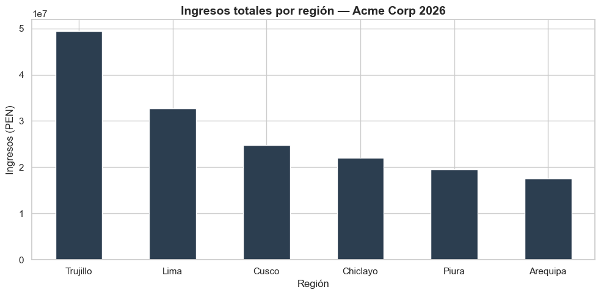

```python
# 1) Gráfico de barras: ingresos por región
fig, ax = plt.subplots(figsize=(10, 5))
ingresos_por_region.plot(kind='bar', ax=ax, color='#2C3E50')
ax.set_title('Ingresos totales por región — Acme Corp 2026', fontweight='bold')
ax.set_xlabel('Región')
ax.set_ylabel('Ingresos (PEN)')
ax.tick_params(axis='x', rotation=0)
plt.tight_layout()
plt.show()
```

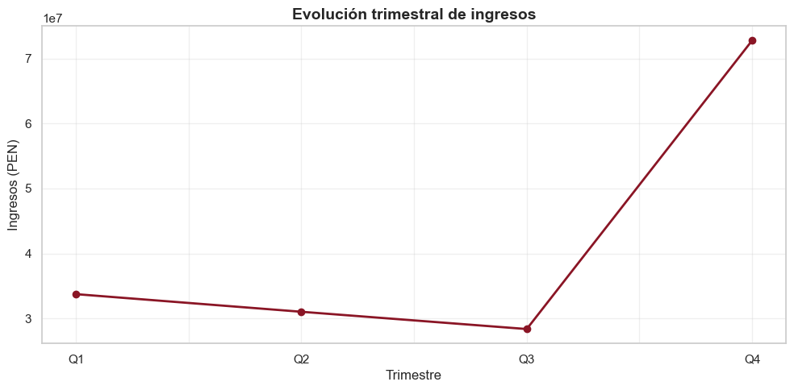

```python
# 2) Gráfico de líneas: tendencia trimestral
ingresos_quarter = df.groupby('quarter')['ingresos'].sum().sort_index()

fig, ax = plt.subplots(figsize=(10, 5))
ingresos_quarter.plot(kind='line', marker='o', ax=ax, color='#8A1525', linewidth=2)
ax.set_title('Evolución trimestral de ingresos', fontweight='bold')
ax.set_xlabel('Trimestre')
ax.set_ylabel('Ingresos (PEN)')
ax.grid(True, alpha=0.3)
plt.tight_layout()
plt.show()
```

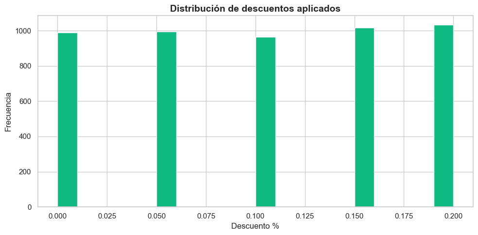

```python
# 3) Histograma: distribución de descuentos
fig, ax = plt.subplots(figsize=(10, 5))
df['descuento_pct'].hist(bins=20, color='#10B981', edgecolor='white', ax=ax)
ax.set_title('Distribución de descuentos aplicados', fontweight='bold')
ax.set_xlabel('Descuento %')
ax.set_ylabel('Frecuencia')
plt.tight_layout()
plt.show()
```

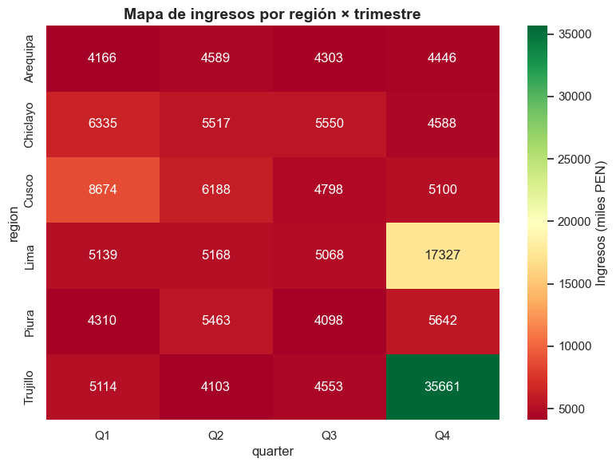

```python
# 4) Heatmap: ingresos por región × quarter
matriz = df.groupby(['region', 'quarter'])['ingresos'].sum().unstack()

fig, ax = plt.subplots(figsize=(8, 6))
sns.heatmap(matriz / 1000, annot=True, fmt='.0f', cmap='RdYlGn', ax=ax,
            cbar_kws={'label': 'Ingresos (miles PEN)'})
ax.set_title('Mapa de ingresos por región × trimestre', fontweight='bold')
plt.tight_layout()
plt.show()
```

### 💡 Pro-Tip: matplotlib vs seaborn

- **matplotlib (`plt.bar`, `df.plot`):** control fino, más verboso. Bueno para reportes.
- **seaborn (`sns.heatmap`, `sns.barplot`):** atajos para gráficos estadísticos comunes. Bueno para EDA rápida.

Ambos coexisten — seaborn está construido sobre matplotlib.

## 7. Heurística: ¿Python o R? 🤔

Después de 8 horas de bilingüismo: ¿cuál usar para qué?

### Cuadro de decisión

| Escenario | Lenguaje recomendado | Razón |
| --- | --- | --- |
| Automatizar reporte mensual integrado a stack BI | **Python** | Mejor integración con Power BI, Azure, AWS, APIs |
| Análisis estadístico clásico (regresiones, ANOVA) | **R** | Ecosistema estadístico maduro (lme4, survey) |
| ML moderno (scikit-learn, XGBoost, deep learning) | **Python** | Stack ML dominante |
| Visualización publicable (paper, conferencia) | **R** | ggplot2 es state-of-the-art |
| Procesamiento ETL nocturno en servidor | **Python** | Mejor tooling de scripting/CLI |
| Encuesta con diseño muestral complejo | **R** | Paquete `survey` no tiene equivalente directo |
| Web scraping + pipeline integrado | **Python** | requests, BeautifulSoup, scrapy |
| Reporte ejecutivo PDF reproducible | **R** | RMarkdown / Quarto + ggplot |
| Trabajas en equipo donde todos usan X | **El que usen** | Friction > optimalidad |

### 🧠 Productive Failure: tus 5 escenarios

**ANTES** de discutir con el grupo, escribe tu decisión (Python / R) para cada uno. Justifica en 1 línea.

1. *"Tu jefe te pide automatizar la limpieza diaria de logs antes de cargarlos a Power BI."*
   - Mi elección: ___
   - Razón: ___
2. *"Necesitas calcular intervalos de confianza por subgrupo y publicarlo en un informe ejecutivo."*
   - Mi elección: ___
   - Razón: ___
3. *"Vas a entrenar un modelo XGBoost para predecir churn de clientes B2B."*
   - Mi elección: ___
   - Razón: ___
4. *"Quieres una visualización publicable para una conferencia sobre patrones de venta regionales."*
   - Mi elección: ___
   - Razón: ___
5. *"Tu equipo BI ya usa Python para todo. Necesitas integrar análisis estadístico al pipeline."*
   - Mi elección: ___
   - Razón: ___

## 8. 🎯 Mini-pipeline integrador (clímax) 🚀

**Es la hora.** Construyes el pipeline completo que responde a tu jefe.

```python
# ============================================================
# PIPELINE: Top 5 productos por ingresos Q4 por región
# ============================================================

def construir_pipeline_top_productos(df: pd.DataFrame,
                                      quarter_objetivo: str = 'Q4',
                                      top_n: int = 5) -> pd.DataFrame:
    """Pipeline reproducible — toma df y devuelve top N productos por región."""
    return (
        df
        # Paso 1: filtrar quarter objetivo
        .query(f"quarter == '{quarter_objetivo}'")
        # Paso 2: limpiar — eliminar registros con cantidad sospechosa (>=1000)
        .loc[lambda d: d['cantidad'] < 1000]
        # Paso 3: agrupar por región × producto, sumar ingresos
        .groupby(['region', 'producto'], as_index=False)
        .agg(ingresos_totales=('ingresos', 'sum'),
             unidades_vendidas=('cantidad', 'sum'))
        # Paso 4: ranking dentro de cada región
        .assign(rank=lambda d: d.groupby('region')['ingresos_totales']
                                .rank(method='dense', ascending=False))
        # Paso 5: quedarse con top N
        .query(f'rank <= {top_n}')
        .sort_values(['region', 'rank'])
        .reset_index(drop=True)
    )

# Ejecutar
top_productos = construir_pipeline_top_productos(df, quarter_objetivo='Q4', top_n=5)
print(f'Resultado: {len(top_productos)} filas (6 regiones × 5 productos = 30)')
top_productos.head(10)
```

```
Resultado: 30 filas (6 regiones × 5 productos = 30)
```

|  | region | producto | ingresos_totales | unidades_vendidas | rank |
| --- | --- | --- | --- | --- | --- |
| 0 | Arequipa | Laptop Pro 15 | 1639021.66 | 400 | 1.00 |
| 1 | Arequipa | Laptop Air 13 | 904612.63 | 315 | 2.00 |
| 2 | Arequipa | Monitor 27 4K | 748258.63 | 468 | 3.00 |
| 3 | Arequipa | Escritorio Ajustable | 491193.22 | 449 | 4.00 |
| 4 | Arequipa | Silla Ergonómica | 291445.97 | 383 | 5.00 |
| 5 | Chiclayo | Laptop Pro 15 | 2041681.08 | 512 | 1.00 |
| 6 | Chiclayo | Laptop Air 13 | 640333.11 | 223 | 2.00 |
| 7 | Chiclayo | Monitor 27 4K | 554394.00 | 356 | 3.00 |
| 8 | Chiclayo | Escritorio Ajustable | 493646.41 | 449 | 4.00 |
| 9 | Chiclayo | Silla Ergonómica | 466469.47 | 623 | 5.00 |

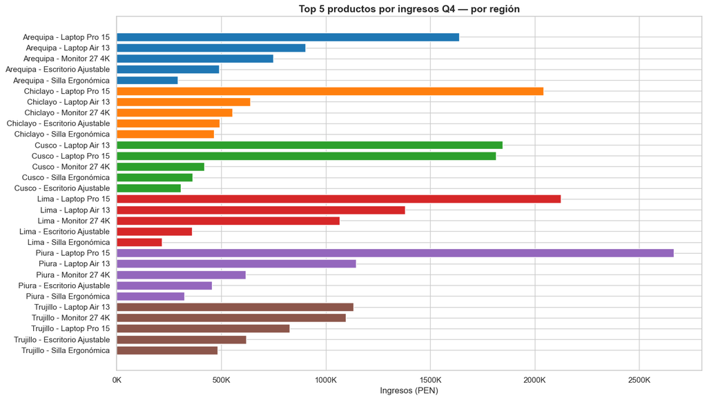

```python
# Visualización del resultado del pipeline
import matplotlib.ticker as mtick

fig, ax = plt.subplots(figsize=(14, 8))

regiones = top_productos['region'].unique()
for i, region in enumerate(sorted(regiones)):
    sub = top_productos[top_productos['region'] == region].sort_values('rank')
    ax.barh(
        [f'{region} - {p}' for p in sub['producto']],
        sub['ingresos_totales'],
        color=plt.cm.tab10(i)
    )

ax.set_title('Top 5 productos por ingresos Q4 — por región', fontweight='bold', fontsize=14)
ax.set_xlabel('Ingresos (PEN)')
ax.xaxis.set_major_formatter(mtick.FuncFormatter(lambda x, _: f'{x/1000:.0f}K'))
ax.invert_yaxis()
plt.tight_layout()
plt.show()
```

```python
# Asserts auto-verificables (CT-07)
assert len(top_productos) <= 30, 'Resultado debe tener máximo 30 filas (6 regiones × 5 productos)'
assert top_productos['ingresos_totales'].min() > 0, 'No deben haber ingresos negativos o cero'
assert top_productos['rank'].max() <= 5, 'Ningún rank debe ser mayor a 5'
assert top_productos.groupby('region').size().max() <= 5, 'Ninguna región tiene más de 5 productos'
print('✅ Pipeline pasa todos los asserts — está listo para producción')
```

```
✅ Pipeline pasa todos los asserts — está listo para producción
```

### 📤 Exportar a Excel para Power BI

Tu jefe usa Power BI. Exportemos el resultado a Excel:

```python
OUTPUT_DIR = Path('../outputs')
OUTPUT_DIR.mkdir(exist_ok=True)

ruta_export = OUTPUT_DIR / 'top5_productos_q4_por_region.xlsx'
top_productos.to_excel(ruta_export, index=False, engine='openpyxl')
print(f'✅ Exportado a: {ruta_export.resolve()}')
```

```
✅ Exportado a: G:\Mi unidad\06Docencia\01Dictado de cursos\01PEBIBA\2026\Fundamentos_Python_R\03Material\02_Sesion_Manipulacion_Pipeline\outputs\top5_productos_q4_por_region.xlsx
```

## 🏆 9. Resumen y siguiente paso

**Hoy aprendiste a:**

1. ✅ Filtrar y seleccionar con `.query()` y `.loc[]`.
2. ✅ Agrupar y agregar con `.groupby() + .agg()`.
3. ✅ Encadenar operaciones con method chaining (legibilidad alta).
4. ✅ Visualizar con matplotlib y seaborn (4 gráficos clave).
5. ✅ Decidir Python vs R con criterio.
6. ✅ Construir un **pipeline reproducible end-to-end** que tu jefe puede ejecutar el lunes.

### Lo que te llevas

- **Una función `construir_pipeline_top_productos()`** que puedes copiar a tu trabajo y adaptar al CSV de tu empresa.
- **Un `.xlsx` exportable** que conecta directamente a Power BI.
- **Una rosetta Python ↔ R** para no perderte cuando veas código del otro lado.
- **Cinco trampas asimétricas** identificadas y mitigadas.

### Para seguir mejorando

1. **Mini-proyecto opcional:** abrir el dataset `acme_ventas_2026Q1.csv` (que NO viste) y replicar el pipeline. Ver `07Evaluación/miniproyecto/enunciado.md`.
2. **VanderPlas (Python Data Science Handbook), capítulos 3 y 4** — referencia canónica para pandas.
3. **Wickham & Grolemund (R for Data Science), capítulos 3-5** — referencia canónica para tidyverse.

### Encuesta de cierre

Por favor completa la encuesta en `07Evaluación/encuesta_post_curso.md` antes de cerrar. Tu feedback alimenta la próxima cohorte.

**¡Felicidades! Pasaste de no tocar código a construir un pipeline reproducible en 8 horas.**

*Cierre Sesión 02 — Fundamentos de Python y R · PEBIBA XVIII · 2026*